# Heart Attack Study

## Spring 2025 Data Science Project

By Kai C, Nathaniel G, Josiah L, Joseph T

### Contributions:

Kai: Contributed to the Project Idea, Dataset Preprocessing, Summary Statistics, and ML Algorithm Training. Contributed to the data preprocessing by using one-hot encoding to convert all string features so that the data can be used for machine learning procedures, the summary statistic that used an ANOVA test, and the ML algorithm training using the KNN classifier and PCA.

Josiah: Found the heart attack dataset for section A, removed NULLs and converted one version of the dataframe to have True/False values from the corresponding 1/0 values, conducted a two sample T test for a hypothesis test for section C, contributed to the discussion on the ML algorithm design and development and helped find the K value for the PCA for section D, plotted the outputs for KNN, PCA, and RandomForest results while explaining the plots and wrote the conclusion and added helpful links for section F, formatted the final tutorial report and wrote comments for most of the sections on the report for section G.

Nathaniel: Wrote a hypothesis test for section C.

Joseph: Contributed to doing most of the PCA & K means & random forest. Plotted out total cumulative variance graph and visualized PCA clustering. Trained random forrest ml model. Debugged code, making sure that there were no mathematical errors within code. Contributed to comments about work done as well as conclustion. Additionally did the chi square data exploration.

## Introduction

According to the [New York Department State of Health](https://www.health.ny.gov/diseases/cardiovascular/heart_disease/), about 805,000 people in the US have a heart attack each year. Therefore, we are trying to predict heart attacks using many different features of a person like cholesterol, heart rate, age etc. The question that our team is trying to answer in our analysis is the following:

> By using a wide range of different health, lifestyle, and demogrphic features, can we predict if someone has a heart attack?

Answering the question is very important because it could help save peoples' lives by determining if we can predict if someone will have a heart attack based on their current features.

## Data Curation

### Data Preprocessing

The dataset file that we are using is from Kaggle and is a csv file that consists of a lot of different features of people like heart rate and blood pressure. Since the dataset file is too large, we will download the csv file (https://www.kaggle.com/datasets/ankushpanday2/heart-attack-prediction-in-united-states) and keep it in the downloads folder.

This particular data set has 372,974 observations and 32 columns, so there is a significant amount of sample data. Our team believes that this data set will provide sufficient data for finding correlations between the many columns, such as demographics and health data points like cholesterol levels to check if someone had a heart attack or not. There is a sufficient amount of data from this data set to provide hypothesis testing, data preprocessing, machine learning analysis, visualization, insights and conclusions in order to predict how and why people have heart attacks.

We will then import pandas, read the csv file, utilize some parsing techniques, and convert it into a Pandas DataFrame.

### Import Libraries (and setting up):

```python
import pandas as pd
import numpy as np
import matplotlib.pyplot as plt
import seaborn as sns
import scipy
import scipy.stats as st

from sklearn.neighbors import KNeighborsClassifier
from sklearn.ensemble import RandomForestClassifier
from sklearn.metrics import accuracy_score, classification_report, confusion_matrix
from sklearn.preprocessing import StandardScaler, OneHotEncoder
from sklearn.model_selection import train_test_split, cross_val_score, StratifiedKFold
from scipy.spatial.distance import cdist
from sklearn.cluster import KMeans
from sklearn.decomposition import PCA
from sklearn import metrics

pd.set_option('display.max_columns', None)
```

### Read CSV file:

```python
heart_attack_df = pd.read_csv('~/Downloads/heart_attack_dataset.csv')
# heart_attack_df = pd.read_csv('heart_attack_dataset.csv')
```

### Remove Rows with NULL values:

```python
heart_attack_df = heart_attack_df.dropna()

print("Rows: " + str(len(heart_attack_df.index)))
```

```
Rows: 372974
```

### Parsing:

We used one-hot encoding to changed all categorical features into binary values of 0 and 1. We also created a seperate dataframe where features with the bool values 1 (True) and 0 (False) we converted to the corresponding boolean value for the hypothesis testing.

```python
# one-hot encoding
for_ml_heart_attack_df = heart_attack_df.copy()
for feature in heart_attack_df.columns:
    if all(isinstance(row, str) for row in for_ml_heart_attack_df[feature]): # should only do one-hot encoding if column has string values
        index = for_ml_heart_attack_df.columns.get_loc(feature)
        count = 0

        # handles edge case of features containing str yes/no values
        if for_ml_heart_attack_df[feature].iloc[0].casefold() == 'yes' or for_ml_heart_attack_df[feature].iloc[0].casefold() == 'no':
            for_ml_heart_attack_df[feature] = for_ml_heart_attack_df[feature].apply(lambda value : 1 if value.casefold() == 'yes' else 0)
        elif feature == 'Outcome': # handles edge case of outcome feature
            for_ml_heart_attack_df[feature] = for_ml_heart_attack_df[feature].apply(lambda value : 1 if value.casefold() == 'heart attack' else 0)
        else: # creates new columns from the one-hot encoding
            dummies = pd.get_dummies(for_ml_heart_attack_df[feature], dtype=int)
            for new_col in dummies:
                # edge case features
                if feature.casefold() == 'diet' or feature.casefold() == 'chestpaintype' or feature.casefold() == 'ecgresults' or feature.casefold() == 'thalassemia' or feature.casefold() == 'thalassemia':
                    for_ml_heart_attack_df.insert(index+count, column=feature+'_'+new_col, value=dummies[new_col].values)
                # all other feaetures
                else:
                    for_ml_heart_attack_df.insert(index+count, column=new_col, value=dummies[new_col].values)
                count+=1

            # remove the old feature
            for_ml_heart_attack_df.drop(feature, axis=1, inplace=True)

display(len(for_ml_heart_attack_df.columns))
display(for_ml_heart_attack_df.head())

# features with bool True/False values
heart_attack_df['Smoker'] = heart_attack_df['Smoker'].apply(lambda value : True if value == 1 else False)
heart_attack_df['Diabetes'] = heart_attack_df['Diabetes'].apply(lambda value : True if value == 1 else False)
heart_attack_df['Hypertension'] = heart_attack_df['Hypertension'].apply(lambda value : True if value == 1 else False)
heart_attack_df['FamilyHistory'] = heart_attack_df['FamilyHistory'].apply(lambda value : True if value == 1 else False)
heart_attack_df['PreviousHeartAttack'] = heart_attack_df['PreviousHeartAttack'].apply(lambda value : True if value == 1 else False)
heart_attack_df['StrokeHistory'] = heart_attack_df['StrokeHistory'].apply(lambda value : True if value == 1 else False)

display(heart_attack_df.head())
```

```
57
```

|  | Age | Female | Male | Cholesterol | BloodPressure | HeartRate | BMI | Smoker | Diabetes | Hypertension | FamilyHistory | PhysicalActivity | AlcoholConsumption | Diet_Healthy | Diet_Moderate | Diet_Unhealthy | StressLevel | Asian | Black | Hispanic | Other | White | Income | College | High School | Postgraduate | Medication | ChestPainType_Asymptomatic | ChestPainType_Atypical | … |
| --- | --- | --- | --- | --- | --- | --- | --- | --- | --- | --- | --- | --- | --- | --- | --- | --- | --- | --- | --- | --- | --- | --- | --- | --- | --- | --- | --- | --- | --- | --- |
| 0 | 31 | 0 | 1 | 194 | 162 | 71 | 22.9 | 0 | 1 | 0 | 0 | 6 | 0 | 0 | 0 | 1 | 1 | 0 | 0 | 1 | 0 | 0 | 64510 | 0 | 1 | 0 | 1 | 0 | 0 | … |
| 1 | 69 | 0 | 1 | 208 | 148 | 93 | 33.9 | 1 | 1 | 0 | 0 | 1 | 2 | 0 | 0 | 1 | 6 | 1 | 0 | 0 | 0 | 0 | 91773 | 1 | 0 | 0 | 0 | 0 | 1 | … |
| 2 | 34 | 1 | 0 | 132 | 161 | 94 | 34.0 | 0 | 0 | 1 | 1 | 1 | 3 | 1 | 0 | 0 | 3 | 0 | 1 | 0 | 0 | 0 | 173550 | 1 | 0 | 0 | 0 | 0 | 0 | … |
| 3 | 53 | 0 | 1 | 268 | 134 | 91 | 35.0 | 0 | 1 | 1 | 0 | 6 | 0 | 1 | 0 | 0 | 3 | 0 | 0 | 1 | 0 | 0 | 43861 | 0 | 1 | 0 | 1 | 0 | 1 | … |
| 4 | 57 | 1 | 0 | 203 | 140 | 75 | 30.1 | 0 | 1 | 0 | 0 | 4 | 1 | 0 | 1 | 0 | 1 | 0 | 0 | 1 | 0 | 0 | 83404 | 0 | 1 | 0 | 1 | 0 | 0 | … |

|  | Age | Gender | Cholesterol | BloodPressure | HeartRate | BMI | Smoker | Diabetes | Hypertension | FamilyHistory | PhysicalActivity | AlcoholConsumption | Diet | StressLevel | Ethnicity | Income | EducationLevel | Medication | ChestPainType | ECGResults | MaxHeartRate | ST_Depression | ExerciseInducedAngina | Slope | NumberOfMajorVessels | Thalassemia | PreviousHeartAttack | StrokeHistory | Residence | … |
| --- | --- | --- | --- | --- | --- | --- | --- | --- | --- | --- | --- | --- | --- | --- | --- | --- | --- | --- | --- | --- | --- | --- | --- | --- | --- | --- | --- | --- | --- | --- |
| 0 | 31 | Male | 194 | 162 | 71 | 22.9 | False | True | False | False | 6 | 0 | Unhealthy | 1 | Hispanic | 64510 | High School | Yes | Typical | ST-T abnormality | 173 | 0.52 | Yes | Downsloping | 1 | Normal | False | False | Suburban | … |
| 1 | 69 | Male | 208 | 148 | 93 | 33.9 | True | True | False | False | 1 | 2 | Unhealthy | 6 | Asian | 91773 | College | No | Atypical | LV hypertrophy | 189 | 3.79 | Yes | Upsloping | 2 | Normal | False | False | Suburban | … |
| 2 | 34 | Female | 132 | 161 | 94 | 34.0 | False | False | True | True | 1 | 3 | Healthy | 3 | Black | 173550 | College | No | Non-anginal | Normal | 122 | 0.17 | Yes | Upsloping | 0 | Normal | True | False | Rural | … |
| 3 | 53 | Male | 268 | 134 | 91 | 35.0 | False | True | True | False | 6 | 0 | Healthy | 3 | Hispanic | 43861 | High School | Yes | Atypical | ST-T abnormality | 104 | 0.67 | Yes | Flat | 0 | Reversible defect | True | False | Suburban | … |
| 4 | 57 | Female | 203 | 140 | 75 | 30.1 | False | True | False | False | 4 | 1 | Moderate | 1 | Hispanic | 83404 | High School | Yes | Typical | ST-T abnormality | 126 | 5.00 | Yes | Flat | 0 | Fixed defect | True | False | Rural | … |

## Exploratory Data Analysis/Data Exploration and Summary Statistics

In this section, we will be exploring the heart attack dataset by doing different types of hypothesis testing. Each of our tests will be looking at specfic features of the dataset.

### Exploration and Summary 1

By Joseph

I will be doing a chi sqare test comparing ethnicity to outcome. my null hypothesis is that ethnicity does not affect outcome and my alternative hypothesis is that ethnicity does affect outcome. I will reject with aplha of 0.05.

But first, i will make a contingency table

```python
elmt, cnt = st.contingency.crosstab(heart_attack_df['Ethnicity'], heart_attack_df['Outcome'])
print(elmt)
print(cnt)
```

```
(array(['Asian', 'Black', 'Hispanic', 'Other', 'White'], dtype=object), array(['Heart Attack', 'No Heart Attack'], dtype=object))
[[37511 37431]
 [37140 37392]
 [37324 37026]
 [37015 37166]
 [37326 37643]]
```

as well as plot its results.

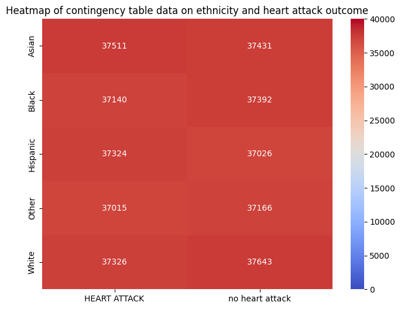

```python
plt.figure(figsize=(8, 6))
sns.heatmap(cnt, annot=True, fmt="d", cmap="coolwarm", vmin=0.0, vmax=40000.0)
plt.title("Heatmap of contingency table data on ethnicity and heart attack outcome")
plt.xticks([i+0.5 for i in range(cnt.shape[1])], ['HEART ATTACK', 'no heart attack'])
plt.yticks([i+0.5 for i in range(cnt.shape[0])], elmt[0])
plt.show()
```

seems quite even...

```python
res = st.chi2_contingency(cnt, correction=False)
res.pvalue
```

```
np.float64(0.48306343081124736)
```

the chi square test gave a p value of 0.48 which is greater than the alpha of 0.05 so we fail to reject the null hypothesis.

### Exploration and Summary 2

By Josiah

I will write a two sided and two sample T test for my hypothesis test based on the independent groups of blood presssures of people that had a previous heart attack and blood pressures of people that did not have a previous heart attack. The alpha value will be 0.05.

- H0: There is no difference between the mean blood pressures of people that had a previous heart attack and the mean blood pressures of people that didn't have a previous heart attack.
- HA: There is a difference between the mean blood pressures of people that had a previous heart attack and the mean blood pressures of people that didn't have a previous heart attack.

If the ratio between the groups are less than 4:1 then we can consider the given groups to have equal variance.

```python
previous_heart_attack = heart_attack_df[heart_attack_df['PreviousHeartAttack'] == True]['BloodPressure']
no_previous_heart_attack = heart_attack_df[heart_attack_df['PreviousHeartAttack'] == False]['BloodPressure']

print("Previous Heart Attack Variance: " + str(np.var(previous_heart_attack)))
print("No Previous Heart Attack Variance: " + str(np.var(no_previous_heart_attack)))
```

```
Previous Heart Attack Variance: 672.9307263333194
No Previous Heart Attack Variance: 677.4239673804153
```

The ratio 677.424:672.931 is less than the 4:1 ratio which allows us to assume a same variance.

```python
# Two sided and two sample T test
stat, p_value = scipy.stats.ttest_ind(a=previous_heart_attack, b=no_previous_heart_attack, equal_var=True)

print("P Value: " + str(p_value))
```

```
P Value: 0.21653200354387594
```

The p-value of 0.217 > alpha value of 0.05, so we fail to reject the null hypothesis that there is no difference between the mean blood pressures of people that had a previous heart attack and the mean blood pressures of people that didn't have a previous heart attack.

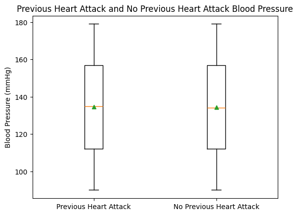

```python
plt.boxplot([previous_heart_attack, no_previous_heart_attack], tick_labels=["Previous Heart Attack", "No Previous Heart Attack"], showmeans=True)
plt.title('Previous Heart Attack and No Previous Heart Attack Blood Pressure')
plt.ylabel('Blood Pressure (mmHg)')
```

### Exploration and Summary 3

By Kai

I will write a new hypothesis test based on four categorical variables, thus, I will be using ANOVA tests.

The following is a hypothesis test for whether the marital status has an effect on the outcome of a heart attack. (Assume $\alpha=0.05$).

- H0: The marital status does not have an effect on the outcome of whether one has a heart attack (i.e., they're independent).
- HA: The martial status does have an effect on the outcome of whether one has a heart attack.

I will first split the data into 4 different dataframes based on marital status.

```python
# to tell me what the categorical variables were
# heart_attack_df['MaritalStatus'].unique()

single = heart_attack_df['MaritalStatus'] == 'Single'
married = heart_attack_df['MaritalStatus'] == 'Married'
widowed = heart_attack_df['MaritalStatus'] == 'Widowed'
divorced = heart_attack_df['MaritalStatus'] == 'Divorced'

# store the proportions of 'No Heart Attack' and 'Heart Attack'
single_proportion = heart_attack_df[single]['Outcome'].value_counts(normalize=True)
married_proportion = heart_attack_df[married]['Outcome'].value_counts(normalize=True)
widowed_proportion = heart_attack_df[widowed]['Outcome'].value_counts(normalize=True)
divorced_proportion = heart_attack_df[divorced]['Outcome'].value_counts(normalize=True)

display([single_proportion, married_proportion, widowed_proportion, divorced_proportion])
```

```
[Outcome
 No Heart Attack    0.500347
 Heart Attack       0.499653
 Name: proportion, dtype: float64,
 Outcome
 Heart Attack       0.500894
 No Heart Attack    0.499106
 Name: proportion, dtype: float64,
 Outcome
 No Heart Attack    0.501075
 Heart Attack       0.498925
 Name: proportion, dtype: float64,
 Outcome
 No Heart Attack    0.5013
 Heart Attack       0.4987
 Name: proportion, dtype: float64]
```

This hypothesis test is one of the only ways to test multiple categorical variables.

```python
# ANOVA test
anova_test = scipy.stats.f_oneway(single, married, widowed, divorced)

anova_test.pvalue
```

```
np.float64(0.1399070014962428)
```

I will create a bar chart to show the relationship between marital status and the outcome of whether one has a heart attack.

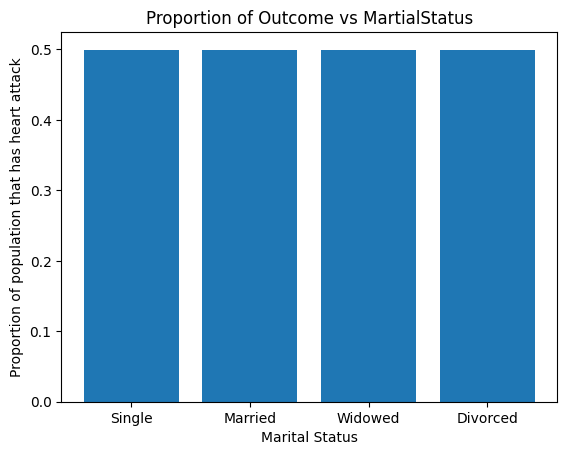

```python
x_var = np.array(['Single', 'Married', 'Widowed', 'Divorced'])
y_var = np.array([single_proportion.iloc[1], married_proportion.iloc[1], widowed_proportion.iloc[1], divorced_proportion.iloc[1]])

plt.bar(x_var, y_var)
plt.title('Proportion of Outcome vs MartialStatus')
plt.xlabel('Marital Status')
plt.ylabel('Proportion of population that has heart attack')
plt.show()
```

Since the p-value = 0.14 > (alpha = 0.05), we fail to reject the null hypothesis.

### Exploration and Summary 4

By Nathaniel

Conducting a hypothesis test to determine whether or not level of cholesterol has an effect on the outcome of a heart attack.

For the purposes of this test, I will assume the population standard deviation is unknown. Therefore I will use a two-sample T-test with level of significance $\alpha=0.05$.

- H0: Above-average cholesterol does not have an effect on the outcome of whether a heart attack occured
- HA: Above-average cholesterol does have an effect on the outcome of whether a heart attack occured.

To conduct this test, the data is split into two samples based on whether or not cholesterol is above the mean of the sample:

```python
#convert object type data to numeric for stats.ttest_ind()
heart_attack_df['outcome_numeric'] = heart_attack_df['Outcome'].map({'No Heart Attack': 0, 'Heart Attack': 1})

mean = heart_attack_df['Cholesterol'].mean()

low_col_df = heart_attack_df[heart_attack_df['Cholesterol'] < mean]['outcome_numeric']
high_col_df = heart_attack_df[heart_attack_df['Cholesterol'] >= mean]['outcome_numeric']
```

```python
t_stat, p_value = scipy.stats.ttest_ind(low_col_df, high_col_df, equal_var=False)
p_value
```

```
np.float64(0.13103144828583682)
```

The p-value (0.131) >= 0.05, indicates no significant difference between the groups. We fail to reject the null hypothesis.

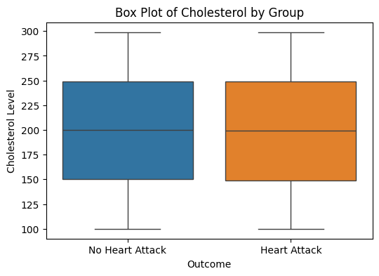

```python
plt.figure(figsize=(6, 4))
plt.xlabel("Outcome")
plt.ylabel("Cholesterol Level")
plt.title("Box Plot of Cholesterol by Group")
sns.boxplot(x="Outcome", y="Cholesterol", data=heart_attack_df, hue="Outcome", legend=False)

plt.show()
```

(There appears to be little difference in the summary statistics for these two groups, thus resulting in the similar boxplots)

```python
print(heart_attack_df.groupby("Outcome")["Cholesterol"].describe())
```

```
                    count        mean        std    min    25%    50%    75%  \
Outcome
Heart Attack     186316.0  199.342504  57.758458  100.0  149.0  199.0  249.0
No Heart Attack  186658.0  199.568976  57.688280  100.0  150.0  200.0  249.0

                   max
Outcome
Heart Attack     299.0
No Heart Attack  299.0
```

Below is a Bar plot that compares the number of those who had heart attacks with those that did not for individuals with above average Cholesterol.

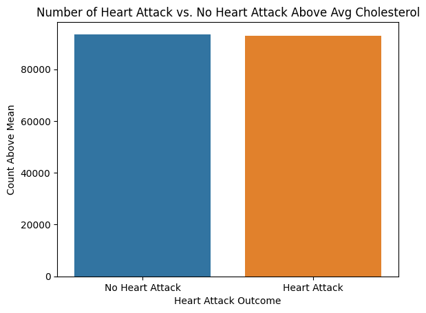

```
Outcome
No Heart Attack    93502
Heart Attack       92870
Name: count, dtype: int64
```

```python
above_mean_df = heart_attack_df[heart_attack_df['Cholesterol'] > mean]

group_counts = above_mean_df['Outcome'].value_counts()

sns.barplot(x=group_counts.index, y=group_counts.values, hue=group_counts.index, legend=False)

plt.xlabel("Heart Attack Outcome")
plt.ylabel("Count Above Mean")
plt.title("Number of Heart Attack vs. No Heart Attack Above Avg Cholesterol")

plt.show()
group_counts
```

## Primary Analysis

### KNN Classifier

We are going to train a KNN classifier model in order to predict whether someone with Kai C.'s features will get a heart attack or not.

```python
# X should be all the features minus outcome, Y should be the outcome
X = for_ml_heart_attack_df.drop('Outcome', axis='columns')
Y = for_ml_heart_attack_df['Outcome']

# Split the data
X_train, X_test, y_train, y_test = train_test_split(X, Y, test_size=0.2)

X_train_no_norm = X_train.copy() # to make sure we have the original data for the KNN

# convert x_train to binary one-hot encoded columns
binary_one_hot_cols = X_train.columns[X_train.apply(lambda col: set(col.unique()) == {0, 1})]
X_train_binary_one_hot = X_train[binary_one_hot_cols]
X_test_binary_one_hot = X_test[binary_one_hot_cols]

# Drop the binary one-hot encoded columns from the original data
X_train_cont = X_train.drop(columns = binary_one_hot_cols)

# Scaling the X data.
scaler = StandardScaler()
X_train = scaler.fit_transform(X_train_cont)
X_test = scaler.transform(X_test[X_train_cont.columns])

# Concat the scaled data with the binary one-hot encoded data and convert to a DataFrame
X_train = np.column_stack((X_train,X_train_binary_one_hot ))
X_test = np.column_stack((X_test,X_test_binary_one_hot ))
```

```python
knn_model = KNeighborsClassifier()

# Perform k-fold Cross-Validation for the knn model
k_folds = 5
skf = StratifiedKFold(n_splits=k_folds, shuffle=True, random_state=42)

# check if knn model is accurate using training data and cross validation
cross_validation_accuracy = cross_val_score(knn_model, X_train, y_train, cv=skf)
print(f"Mean: {cross_validation_accuracy.mean()}")
print(f"Standard deviation: {cross_validation_accuracy.std()}")

# check if knn model is accurate using test data and cross validation
cross_validation_accuracy = cross_val_score(knn_model, X_test, y_test, cv=skf)
print(f"Mean: {cross_validation_accuracy.mean()}")
print(f"Standard deviation: {cross_validation_accuracy.std()}")

# now we see if our knn model predicts if someone with Kai's features will get a heart attack or not
knn_model.fit(X_train, y_train)

# predict Kai C.'s heart attack outcome
predict_kai = knn_model.predict(np.array([21, 0, 1, 130, 140, 70,
       21, 0, 0, 0, 0,
       2, 0, 0,
       1, 0, 3, 1, 0,
       0, 0, 0, 10000, 1, 0,
       0, 0, 0,
       0, 0,
       0, 0,
       0, 0, 180,
       0, 0, 0, 0,
       0, 2, 0,
       0, 0,
       0, 0, 0, 1, 0,
       0, 0, 1, 0, 0, 1,
       0]).reshape(1, -1))

display("Kai will get a heart attack" if predict_kai == 1 else "Kai will not get a heart attack")
```

```
Mean: 0.4994553814168638
Standard deviation: 0.0018367872540449926
Mean: 0.49854547891949863
Standard deviation: 0.002041635027531844
```

```
'Kai will not get a heart attack'
```

If the cross-validation score of the mean is above 0.9 for both training and test data, then it has done well with the training data. The cross-validation scores are way below 0.9 for both the training and the test data so this shows that the KNN classifier is not very accurate in predicting whether someone will get a heart attack or not.

## Visualization (KNN)

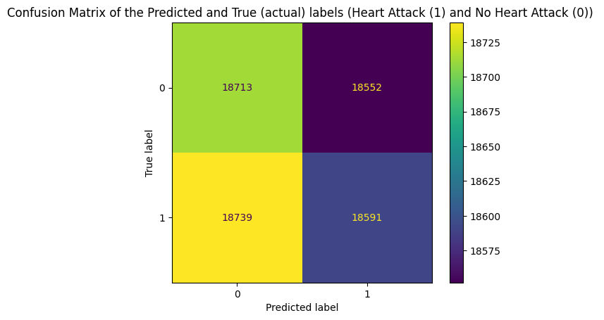

```python
# KNN model predictions based on the test data.
y_pred = knn_model.predict(X_test)

# Creates the confusion matrix.
conf_mat = confusion_matrix(y_test, y_pred)

# Plots the confusion matrix.
metrics.ConfusionMatrixDisplay(confusion_matrix=conf_mat).plot()
plt.title('Confusion Matrix of the Predicted and True (actual) labels (Heart Attack (1) and No Heart Attack (0)) ')
```

This displayed confusion matrix as a heatmap plot shows that relatively there are a lot of false positive (when the True label is 0 (no heart attack) but was marked as a 1 (heart attack) for the Predicted label) compared to the number of correct predictions of heart attacks (Both True label and Predicted label are marked as 1 (heart attack)). The displayed confusion matrix also shows that relatively there are a lot of false negatives (when the Predicted label is marked as 0 (no heart attack) but the True label was marked as 1 (heart attack)) compared to the number of correct predictions of no heart attack (Both True label and Predicted label are marked as 0 (no heart attack)). This shows that our KNN classifier is inaccurate in determining if someone has a heart attack or not.

### PCA

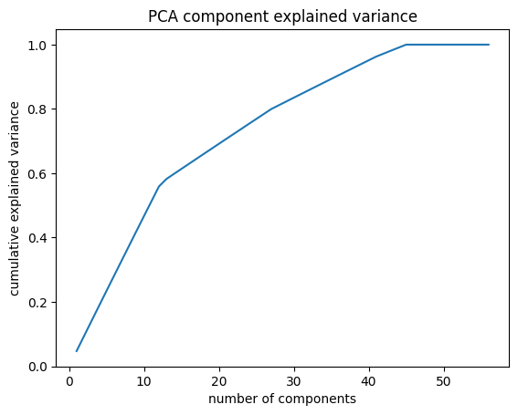

```python
seed = 42

pca = PCA()
pca.fit(X_train)

plt.figure()
plt.plot(range(1,len(pca.explained_variance_ratio_) + 1), pca.explained_variance_ratio_.cumsum())

plt.title("PCA component explained variance")
plt.xlabel("number of components")
plt.ylabel("cumulative explained variance")
```

This shows that there isnt any good single thing that explains varaince well. The first 13 or so components seem to explain relatively large amounts of variance before tapering off. I choose to use the first 30 components as that gives me around 80% of the variance.

Next, I start the K means. In order to find the best # of clusters, I use the elbow method to plot out the intertias and distortions of varying # of clusters.

```python
pca = PCA(n_components=30)
X_pca = pca.fit_transform(X_train)

# Variables used to assist the elbow method
distortions = []
inertias = []
K = range(1, 10)

# Loop through the range of K values to find the elbow point (aka optimal K)
for k in K:
    kmeans_model = KMeans(n_clusters=k)
    kmeans_model.fit(X_pca)

    # Get the distortions and inertias
    distortions.append(sum(np.min(cdist(X_pca, kmeans_model.cluster_centers_, metric='euclidean')**2, axis=1)))
    inertias.append(kmeans_model.inertia_)
```

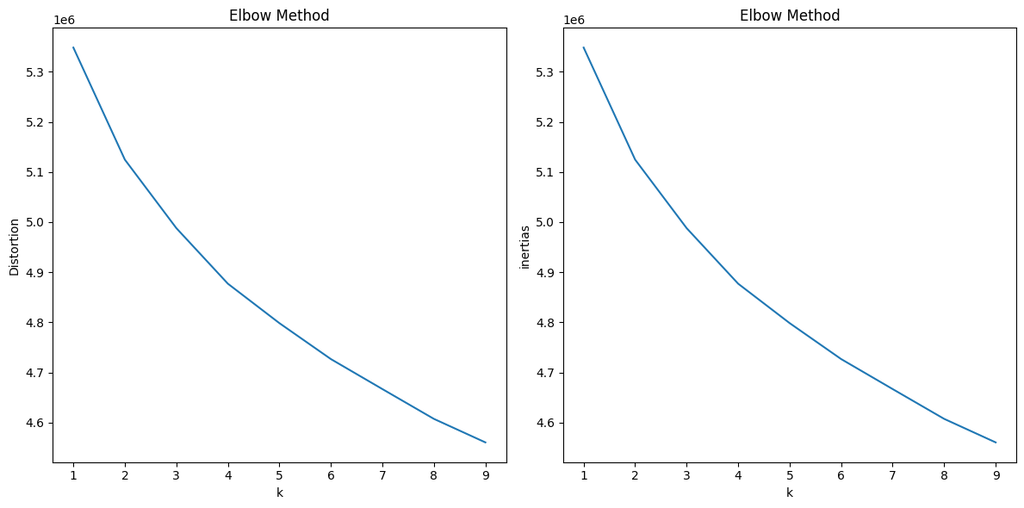

```python
# Plot the Distortion and Inertias based on the k values.

fig, ax = plt.subplots(1, 2, figsize=(12, 6))
ax[0].plot(K, distortions)
ax[0].set_xlabel('k')
ax[0].set_ylabel('Distortion')
ax[0].set_title("Elbow Method")

ax[1].plot(K, inertias)
ax[1].set_xlabel('k')
ax[1].set_ylabel('inertias')
ax[1].set_title("Elbow Method")
plt.tight_layout()
plt.show()
```

Based on the elbow method, our team will be using a k = 2 which is the number of clusters that we will use.

```python
X_train.shape
```

```
(298379, 56)
```

## Visualizations (PCA)

Now we will plot the clusters.

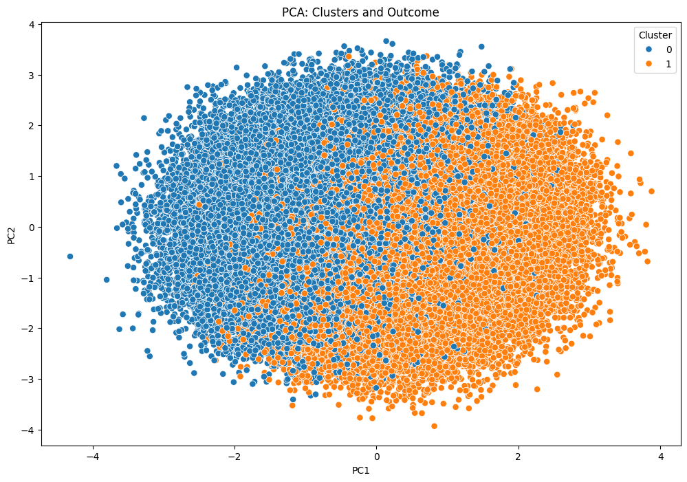

```python
def plot_clusters(Xer,  title, xlabel, ylabel, for_ml_df_0):
    for_ml_df = pd.DataFrame(for_ml_df_0, columns=X.columns)
    plt.subplots(figsize=(12, 8))
    kmeans = KMeans(n_clusters=2, random_state=seed).fit(Xer)
    for_ml_df['Cluster'] = pd.Categorical(kmeans.labels_)
    sns.scatterplot(x=Xer[:, 0],y=Xer[:, 1], hue="Cluster", data=for_ml_df,s=45,legend="full")

    plt.title(title)
    plt.xlabel(xlabel)
    plt.ylabel(ylabel)
    plt.show()

plotclusterxtrain = X_train.copy()
plot_clusters(X_pca, 'PCA: Clusters and Outcome', 'PC1', 'PC2', plotclusterxtrain)
```

There seems to be a relatively clean split off of the first two components. Not particularly good as this means that the k means are not mostly clustering on only these two PCs and not learning much of the overall shape of the data.

```python
continuous_features = X_train_cont.columns
binary_features = binary_one_hot_cols


components = pca.components_

features = list(continuous_features) + list(binary_features)
pca_loadings = pd.DataFrame(components, columns=features)
pca_loadings
```

|  | Age | Cholesterol | BloodPressure | HeartRate | BMI | PhysicalActivity | AlcoholConsumption | StressLevel | Income | MaxHeartRate | ST_Depression | NumberOfMajorVessels | Female | Male | Smoker | Diabetes | Hypertension | FamilyHistory | Diet_Healthy | Diet_Moderate | Diet_Unhealthy | Asian | Black | Hispanic | Other | White | College | High School | Postgraduate | … |
| --- | --- | --- | --- | --- | --- | --- | --- | --- | --- | --- | --- | --- | --- | --- | --- | --- | --- | --- | --- | --- | --- | --- | --- | --- | --- | --- | --- | --- | --- | --- |
| 0 | 0.244152 | 0.581182 | 0.384116 | 0.186705 | 0.158682 | -0.298191 | 0.121334 | 0.115180 | 0.295107 | 0.359193 | -0.168571 | 0.183134 | 0.002529 | -0.002529 | 0.000401 | -0.000189 | -0.000357 | 0.000301 | 0.000138 | 0.001942 | -0.002080 | 0.000942 | -0.001084 | 0.000483 | -0.000038 | -0.000304 | -0.000323 | 0.000075 | 0.000248 | … |
| 1 | 0.037891 | -0.259819 | 0.109496 | -0.115930 | -0.438116 | -0.252142 | 0.377022 | 0.507811 | -0.206658 | 0.089174 | 0.196152 | 0.401105 | 0.001614 | -0.001614 | -0.001016 | -0.000610 | 0.000700 | 0.000053 | -0.001382 | 0.000556 | 0.000826 | -0.000207 | 0.000940 | -0.000265 | 0.000820 | -0.001288 | 0.000892 | -0.000181 | -0.000711 | … |
| 2 | -0.491149 | -0.063239 | 0.254415 | 0.563998 | -0.291694 | 0.024455 | -0.258467 | 0.089778 | 0.066590 | 0.273872 | 0.275680 | -0.236365 | -0.001175 | 0.001175 | 0.003276 | 0.000059 | 0.001315 | 0.000376 | 0.000635 | -0.000044 | -0.000591 | -0.000009 | -0.000374 | 0.001323 | -0.000459 | -0.000482 | -0.001748 | 0.002037 | -0.000289 | … |
| 3 | 0.397723 | 0.064287 | 0.391687 | -0.319826 | -0.339862 | 0.360676 | -0.263983 | 0.103294 | 0.333104 | -0.173622 | 0.299466 | -0.158682 | 0.003382 | -0.003382 | -0.000306 | 0.002076 | -0.001181 | 0.000753 | -0.001074 | 0.000407 | 0.000667 | -0.000420 | 0.000447 | 0.001113 | -0.000344 | -0.000796 | 0.000357 | -0.002014 | 0.001657 | … |
| 4 | 0.034893 | -0.297926 | -0.069917 | -0.312110 | 0.063583 | -0.115943 | -0.354410 | 0.404820 | 0.064080 | 0.463669 | -0.431047 | -0.309482 | 0.003621 | -0.003621 | -0.000488 | 0.000356 | -0.001283 | 0.000106 | 0.001428 | -0.001013 | -0.000415 | -0.000822 | -0.000219 | 0.000657 | -0.000217 | 0.000600 | -0.001848 | -0.000177 | 0.002025 | … |
| 5 | 0.225977 | 0.287994 | -0.336323 | 0.049252 | 0.261271 | 0.319343 | -0.097064 | 0.287467 | -0.379707 | 0.347811 | 0.471763 | -0.018942 | -0.002522 | 0.002522 | -0.001061 | 0.000653 | -0.000761 | 0.000355 | -0.002673 | 0.000638 | 0.002036 | 0.001115 | -0.000100 | -0.001062 | -0.000028 | 0.000075 | -0.000138 | 0.002441 | -0.002303 | … |
| 6 | -0.303274 | -0.011807 | -0.301981 | -0.052082 | 0.129208 | 0.342761 | 0.407989 | 0.270598 | 0.659030 | 0.050261 | 0.052383 | 0.021638 | -0.000238 | 0.000238 | -0.001584 | -0.000389 | -0.001160 | 0.002201 | 0.001119 | -0.001989 | 0.000870 | -0.000638 | -0.000510 | -0.000213 | 0.000429 | 0.000931 | 0.000131 | 0.000545 | -0.000676 | … |
| 7 | -0.129714 | -0.061092 | 0.153837 | 0.075329 | 0.022554 | 0.524230 | -0.308934 | 0.020836 | -0.079982 | 0.071411 | -0.332233 | 0.675977 | 0.002807 | -0.002807 | 0.001033 | 0.002850 | 0.000085 | -0.000213 | -0.001241 | -0.000930 | 0.002172 | -0.000817 | -0.000304 | 0.000428 | -0.002058 | 0.002750 | 0.001668 | -0.000747 | -0.000921 | … |
| 8 | -0.230104 | -0.046936 | 0.230487 | -0.066781 | 0.551710 | -0.255293 | -0.287168 | 0.406054 | 0.040807 | -0.446928 | 0.237719 | 0.111289 | -0.000481 | 0.000481 | -0.000476 | 0.001127 | -0.001290 | 0.001460 | -0.000001 | -0.002454 | 0.002455 | -0.000831 | 0.000107 | 0.000372 | -0.000248 | 0.000600 | -0.000584 | -0.000461 | 0.001045 | … |
| 9 | -0.414502 | 0.144442 | 0.477136 | -0.455024 | 0.152483 | 0.222677 | 0.333714 | -0.107744 | -0.320387 | 0.180079 | -0.001686 | -0.204045 | -0.000138 | 0.000138 | 0.000823 | -0.000403 | 0.000678 | -0.001952 | -0.002259 | 0.001310 | 0.000949 | 0.002490 | 0.000138 | -0.000267 | -0.001198 | -0.001164 | -0.002944 | 0.000072 | 0.002872 | … |
| 10 | 0.340249 | -0.289601 | 0.274319 | 0.459531 | 0.217484 | 0.299110 | 0.336580 | 0.251281 | -0.153485 | -0.179988 | -0.247783 | -0.288652 | 0.001583 | -0.001583 | 0.000463 | 0.000446 | -0.000488 | 0.001009 | 0.000159 | -0.002565 | 0.002406 | 0.001513 | -0.000628 | 0.000775 | -0.000920 | -0.000740 | 0.001897 | -0.001512 | -0.000385 | … |
| 11 | -0.194539 | 0.551362 | -0.182579 | 0.018351 | -0.343171 | 0.069300 | -0.050461 | 0.387639 | -0.194611 | -0.386863 | -0.357672 | -0.183235 | 0.001301 | -0.001301 | -0.002975 | 0.000658 | -0.001521 | 0.000364 | 0.001500 | -0.000527 | -0.000973 | 0.001032 | -0.002124 | 0.000382 | 0.000455 | 0.000255 | -0.000321 | -0.001181 | 0.001502 | … |
| 12 | -0.003326 | 0.000540 | -0.004661 | 0.002300 | 0.002659 | -0.001206 | 0.001523 | -0.003982 | -0.002554 | -0.000747 | 0.005810 | -0.001348 | 0.706928 | -0.706928 | -0.002106 | -0.003455 | 0.000271 | -0.001663 | 0.001128 | -0.005487 | 0.004359 | 0.000678 | -0.000009 | 0.000371 | 0.001060 | -0.002100 | -0.000155 | -0.002982 | 0.003137 | … |
| 13 | 0.000195 | -0.001604 | 0.002251 | -0.000899 | -0.002509 | 0.000735 | -0.001168 | 0.000358 | 0.001367 | -0.003357 | -0.000533 | 0.000068 | 0.003861 | -0.003861 | 0.002415 | -0.008812 | -0.009523 | -0.000988 | -0.023095 | 0.081711 | -0.058616 | -0.000842 | -0.001744 | 0.003013 | 0.001899 | -0.002325 | -0.230702 | 0.502450 | -0.271749 | … |
| 14 | -0.000677 | -0.002732 | -0.000974 | 0.001484 | -0.001176 | 0.000866 | -0.000651 | 0.000582 | 0.001263 | -0.000714 | -0.001521 | -0.000143 | 0.002229 | -0.002229 | -0.002043 | -0.002550 | -0.004449 | 0.007494 | -0.421369 | 0.469013 | -0.047644 | 0.001481 | -0.001129 | 0.004359 | -0.003753 | -0.000957 | 0.103251 | -0.087739 | -0.015512 | … |
| 15 | 0.001424 | 0.001021 | 0.002254 | -0.000951 | -0.000635 | -0.000102 | -0.000628 | -0.000593 | -0.001127 | 0.001510 | -0.000417 | -0.001465 | -0.000792 | 0.000792 | 0.009697 | 0.000533 | -0.008465 | 0.001916 | 0.115133 | -0.328330 | 0.213196 | 0.005413 | 0.001909 | 0.003697 | -0.007394 | -0.003626 | 0.115032 | 0.230774 | -0.345807 | … |
| 16 | -0.000447 | -0.000744 | 0.000729 | 0.001561 | 0.001779 | -0.000520 | -0.000973 | -0.000779 | -0.001891 | 0.000782 | 0.001036 | -0.001458 | 0.004662 | -0.004662 | -0.014108 | 0.002278 | 0.004966 | -0.005465 | -0.201190 | 0.147697 | 0.053493 | 0.006691 | -0.002775 | -0.002689 | 0.000092 | -0.001320 | 0.085113 | -0.102210 | 0.017097 | … |
| 17 | -0.000070 | 0.003385 | 0.001209 | -0.003685 | 0.002112 | -0.002733 | -0.001092 | -0.001462 | -0.002580 | -0.000740 | -0.000886 | -0.002032 | -0.000466 | 0.000466 | 0.001332 | -0.000938 | -0.003419 | -0.005137 | -0.196589 | 0.056188 | 0.140401 | 0.002052 | -0.000700 | -0.002863 | 0.004549 | -0.003039 | -0.087207 | 0.290658 | -0.203451 | … |
| 18 | 0.000380 | 0.002359 | -0.000312 | -0.000694 | -0.002457 | -0.000659 | -0.000699 | -0.001773 | -0.001311 | 0.000646 | 0.000639 | 0.000626 | -0.005316 | 0.005316 | 0.000669 | 0.000597 | -0.002065 | 0.000937 | -0.053258 | -0.339100 | 0.392358 | 0.000621 | -0.004849 | -0.000971 | 0.003079 | 0.002120 | -0.246758 | 0.024567 | 0.222191 | … |
| 19 | 0.003697 | 0.002036 | -0.000239 | -0.000803 | 0.004187 | 0.002085 | -0.000607 | 0.001112 | -0.001347 | 0.000359 | 0.000025 | 0.000466 | 0.001933 | -0.001933 | -0.000529 | 0.004926 | 0.007959 | -0.003256 | 0.013740 | 0.196383 | -0.210123 | -0.004342 | 0.002093 | 0.003279 | -0.004593 | 0.003564 | -0.164281 | -0.144109 | 0.308390 | … |
| 20 | -0.001230 | 0.001796 | -0.001706 | 0.002306 | 0.000709 | -0.002640 | -0.001071 | -0.002376 | 0.001657 | -0.000688 | 0.000253 | -0.001794 | -0.000216 | 0.000216 | -0.012948 | 0.006718 | 0.006806 | -0.003378 | -0.176756 | -0.047386 | 0.224142 | -0.000136 | 0.003922 | -0.002051 | -0.001899 | 0.000165 | -0.138172 | -0.051879 | 0.190051 | … |
| 21 | 0.000693 | 0.003452 | -0.000886 | -0.000902 | -0.000176 | -0.000860 | -0.000464 | -0.001172 | -0.000183 | 0.000380 | 0.002067 | 0.000588 | 0.004312 | -0.004312 | 0.007651 | -0.005267 | 0.002560 | -0.003954 | 0.026962 | -0.132557 | 0.105595 | -0.001606 | 0.000812 | -0.000743 | 0.001063 | 0.000474 | 0.337648 | -0.204932 | -0.132716 | … |
| 22 | 0.002902 | -0.001504 | 0.000973 | -0.000968 | 0.001494 | 0.001978 | -0.000737 | -0.001554 | -0.001702 | -0.001144 | 0.001644 | 0.002603 | -0.000617 | 0.000617 | 0.008815 | -0.007474 | -0.004191 | 0.001107 | 0.333134 | -0.192579 | -0.140555 | -0.002892 | 0.000595 | 0.000652 | 0.003959 | -0.002314 | -0.126329 | 0.019176 | 0.107153 | … |
| 23 | 0.003040 | -0.000051 | -0.001606 | 0.001642 | -0.000402 | -0.000208 | 0.003149 | -0.000860 | 0.002100 | 0.003201 | -0.003738 | 0.001554 | 0.005996 | -0.005996 | 0.000789 | -0.001417 | -0.003844 | 0.005916 | 0.035646 | -0.212093 | 0.176447 | 0.008203 | -0.002024 | 0.004013 | -0.005228 | -0.004963 | -0.148888 | 0.059767 | 0.089121 | … |
| 24 | -0.001536 | 0.001505 | 0.001396 | -0.003186 | 0.001128 | -0.001373 | -0.001070 | -0.000384 | 0.001210 | 0.001209 | -0.002406 | -0.003137 | -0.001817 | 0.001817 | -0.010691 | -0.001282 | -0.003375 | -0.004596 | -0.128354 | -0.072405 | 0.200758 | -0.001568 | -0.002174 | -0.003801 | 0.000360 | 0.007183 | 0.514183 | -0.159989 | -0.354194 | … |
| 25 | 0.000532 | -0.001476 | -0.000691 | 0.001412 | -0.002481 | -0.001471 | -0.000209 | -0.000428 | 0.001819 | 0.000168 | 0.000150 | 0.000696 | -0.004064 | 0.004064 | -0.012398 | -0.000091 | -0.003165 | -0.006087 | -0.355794 | -0.114659 | 0.470453 | 0.006250 | -0.005202 | 0.000553 | 0.002869 | -0.004469 | -0.067643 | -0.195198 | 0.262840 | … |
| 26 | 0.003447 | -0.000333 | -0.001571 | 0.000808 | 0.001559 | 0.001180 | 0.000974 | 0.001414 | 0.003232 | -0.002655 | -0.003643 | 0.001201 | 0.002932 | -0.002932 | 0.005515 | -0.003472 | -0.002888 | -0.006282 | -0.324727 | 0.182135 | 0.142593 | 0.004905 | -0.007037 | 0.000133 | 0.000729 | 0.001269 | -0.215126 | 0.352080 | -0.136955 | … |
| 27 | -0.001528 | 0.001948 | -0.001532 | -0.000446 | -0.001581 | 0.001714 | 0.000324 | 0.000501 | -0.000702 | -0.000749 | 0.001180 | 0.000286 | 0.000021 | -0.000021 | 0.418859 | -0.315317 | -0.159423 | -0.275807 | -0.013017 | 0.000504 | 0.012514 | 0.005888 | 0.005386 | -0.002608 | -0.006602 | -0.002064 | 0.000994 | -0.006535 | 0.005541 | … |
| 28 | 0.002156 | -0.000917 | 0.000768 | -0.000751 | -0.000907 | -0.003188 | 0.001792 | 0.000469 | -0.000015 | 0.000630 | 0.000556 | 0.002611 | 0.002049 | -0.002049 | 0.225064 | -0.178531 | -0.125232 | -0.014612 | -0.003185 | 0.003062 | 0.000123 | -0.007206 | 0.003179 | 0.008300 | 0.001728 | -0.006001 | 0.001156 | -0.001294 | 0.000138 | … |
| 29 | 0.001107 | -0.000647 | -0.000382 | 0.001431 | -0.000160 | 0.000936 | 0.000940 | 0.000769 | 0.000528 | 0.001783 | 0.001435 | 0.001516 | -0.001111 | 0.001111 | -0.071439 | 0.067714 | 0.500159 | -0.285506 | -0.000370 | 0.001559 | -0.001189 | -0.001138 | 0.009838 | -0.002222 | -0.011092 | 0.004614 | -0.000959 | 0.007942 | -0.006982 | … |

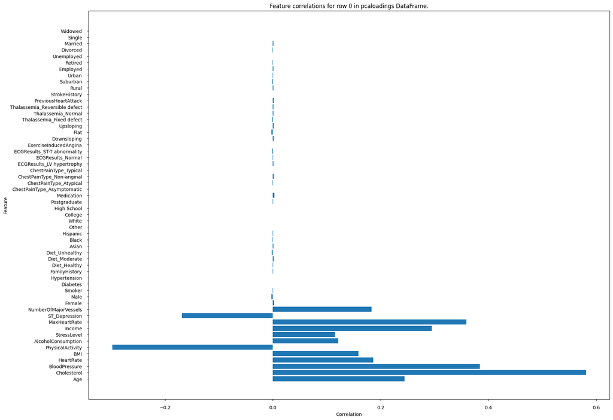

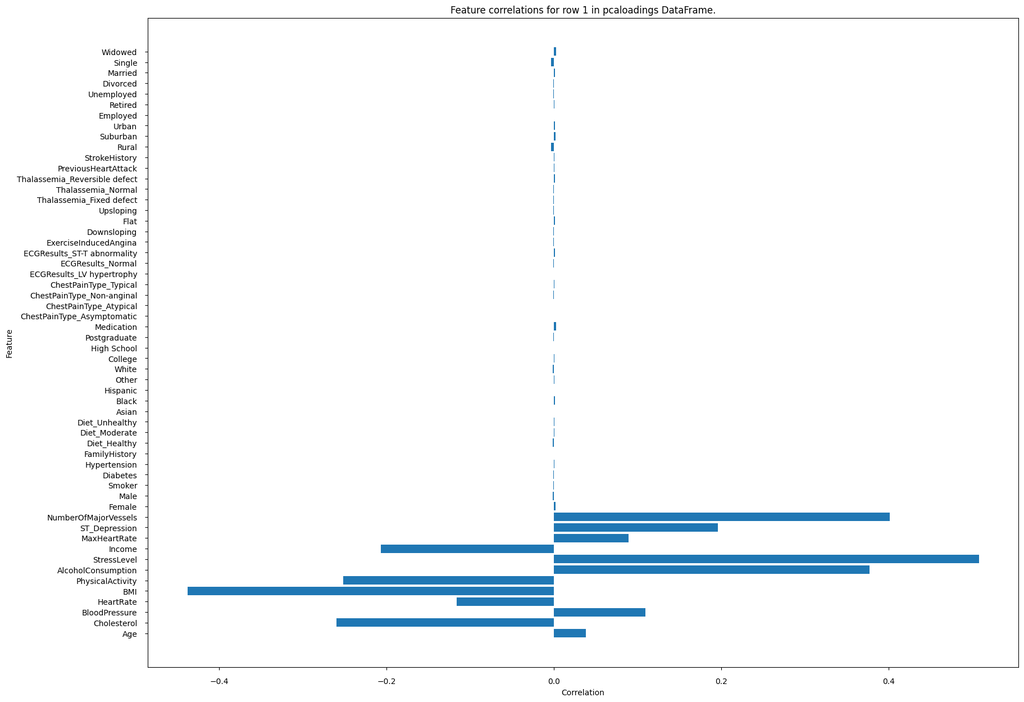

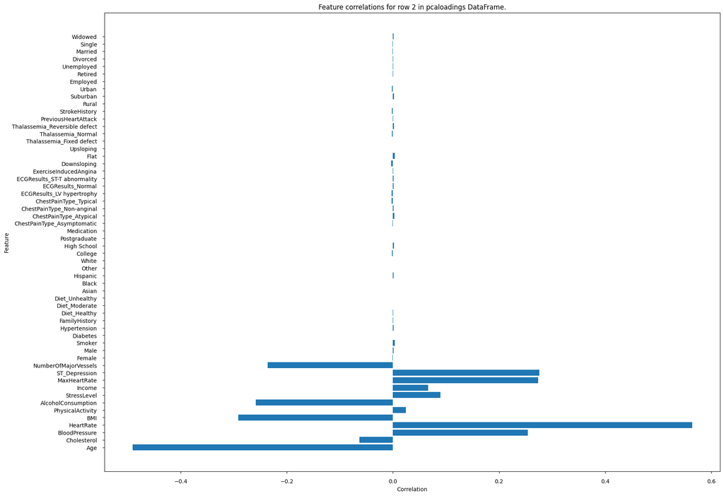

```python
top_pcas = pca_loadings.head(3)

for index, row in top_pcas.iterrows():

    figure, axes = plt.subplots(figsize=(20, 15))

    bar_plot = axes.barh(features, row)

    axes.xaxis.set_tick_params(pad=10)
    axes.yaxis.set_tick_params(pad=10)

    axes.set_xlabel("Correlation")
    axes.set_ylabel("Feature")
    axes.set_title("Feature correlations for row " + str(index) + " in pcaloadings DataFrame.")
```

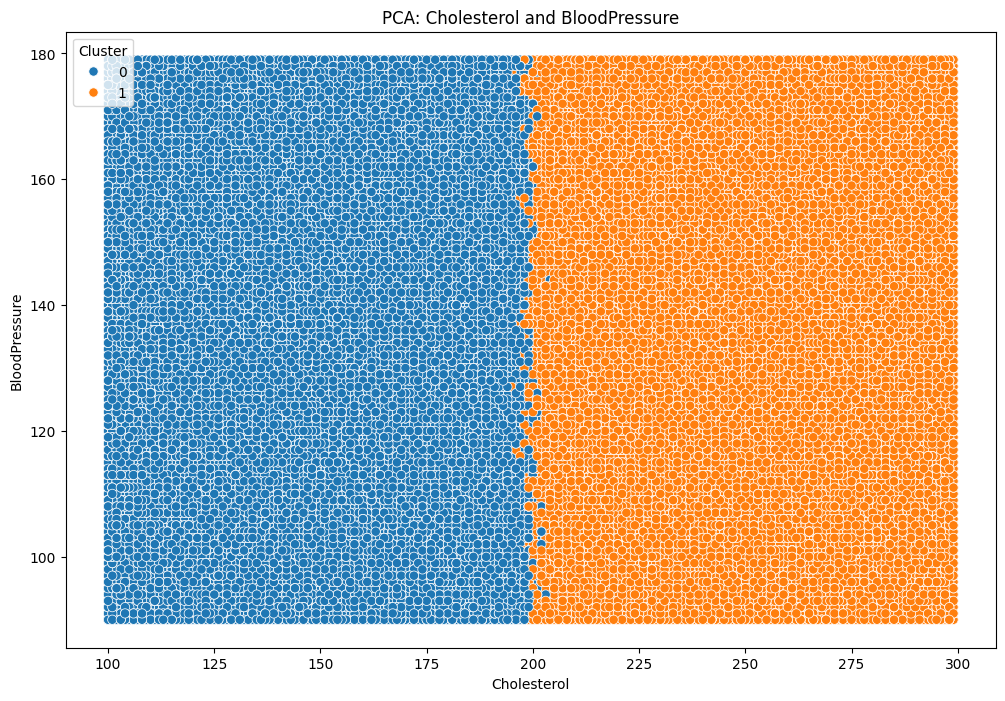

```python
def plot_clusters(Xer,  title, xlabel, ylabel, for_ml_df_0):

    for_ml_df = pd.DataFrame(for_ml_df_0, columns=list(continuous_features) + list(binary_features))
    plt.subplots(figsize=(12, 8))
    kmeans = KMeans(n_clusters=2, random_state=seed).fit(Xer)
    for_ml_df['Cluster'] = pd.Categorical(kmeans.labels_)
    sns.scatterplot(x=for_ml_df["Cholesterol"],y=for_ml_df["BloodPressure"], hue="Cluster", data=for_ml_df,s=45,legend="full")

    plt.title(title)
    plt.xlabel(xlabel)
    plt.ylabel(ylabel)
    plt.show()

plotclusterxtrain = X_train_no_norm.copy()
plot_clusters(X_pca, 'PCA: Cholesterol and BloodPressure', 'Cholesterol', 'BloodPressure', plotclusterxtrain)
```

This plot shows visual confirmation that the PCA is splitting on the Cholesterol feature.

Below we are one hot encoding the cluster before adding it to the dataset. One hot encoding is not as neccesary now because there are only 2 clusters but previously we had more clusters and such code was necessary to not have the model analyze the cluster number as ordinal data. (one hot encoding adds an extra feature now which might makes things harder to learn for the model but is also fancier)

Though the k means doesnt seem to have learned much that was already known, we are still including it anyways just in case.

```python
# applying one hot to the k means cluster.

X_pca_te = pca.transform(X_test)

kmeans = KMeans(n_clusters=2, random_state=seed).fit(X_pca)

cluster_labels_tr = kmeans.predict(X_pca)
cluster_labels_te = kmeans.predict(X_pca_te)

cluster_labels_tr = cluster_labels_tr.reshape(-1, 1)
cluster_labels_te = cluster_labels_te.reshape(-1, 1)

encoder = OneHotEncoder()

cluster_labels_tr_one_hot = encoder.fit_transform(cluster_labels_tr).toarray()
cluster_labels_te_one_hot = encoder.transform(cluster_labels_te).toarray()
X_train_c = np.hstack((X_train,cluster_labels_tr_one_hot ))
X_test_c = np.hstack((X_test,cluster_labels_te_one_hot ))
```

### RandomForestClassifier

We will now be using a RandomForestClassifier as another machine learning technique to try to predict heart attack outcomes. The additional feature added by k means clustering is also included.

```python
model = RandomForestClassifier(random_state=seed)

k_folds = 5
skf = StratifiedKFold(n_splits=k_folds, shuffle=True, random_state=seed)

score = cross_val_score(model, X_train_c, y_train, cv=skf)
print(f'RandomForestClassifier: mean = {np.mean(score)}, std = {np.std(score)}')
```

```
RandomForestClassifier: mean = 0.4999782179726394, std = 0.0006909500318041592
```

```python
model = model.fit(X_train_c, y_train)
```

```python
y_pred = model.predict(X_test_c)
accuracy = accuracy_score(y_test ,y_pred)

print(f"Accuracy of RandomForestClassifier: {accuracy:.3f}")
print(classification_report(y_test, y_pred))
```

```
Accuracy of RandomForestClassifier: 0.503
              precision    recall  f1-score   support

           0       0.50      0.55      0.52     37265
           1       0.50      0.46      0.48     37330

    accuracy                           0.50     74595
   macro avg       0.50      0.50      0.50     74595
weighted avg       0.50      0.50      0.50     74595
```

The accuracy, precision, recall, f1-score all have really low values which shows that the Random Forest Classifier is not good in predicting if someone has a heart attack or not. Around the same accuracy as the KNN from before. Perhaps it is very hard to predict.

## Visualization (Random Forest)

We will now be plotting a confusion matrix as a heatmap to show the instances of each of the predictions of whether someone has a heart attack or not compared to the actual scenario when someone either has a heart attack or not.

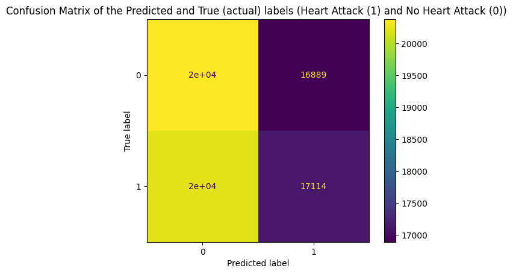

```python
# Creates the confusion matrix
conf_mat = confusion_matrix(y_test, y_pred)

# Plots the confusion matrix
metrics.ConfusionMatrixDisplay(confusion_matrix=conf_mat).plot()
plt.title('Confusion Matrix of the Predicted and True (actual) labels (Heart Attack (1) and No Heart Attack (0)) ')
```

This displayed confusion matrix as a heatmap plot shows that relatively there are a lot of false positive (when the True label is 0 (no heart attack) but was marked as a 1 (heart attack) for the Predicted label) compared to the number of correct predictions of heart attacks (Both True label and Predicted label are marked as 1 (heart attack)). The displayed confusion matrix also shows that relatively there are a lot of false negatives (when the Predicted label is marked as 0 (no heart attack) but the True label was marked as 1 (heart attack)) compared to the number of correct predictions of no heart attack (Both True label and Predicted label are marked as 0 (no heart attack)). This shows that our Random Forest Classifier is inaccurate in determining if someone has a heart attack or not.

## Insights and Conclusions

After our team's analysis, we have found that it is very difficult to predict whether someone has a heart attack or not from a wide range of features such as health features like blood pressure and heart rate and also other types of features such as specific demographics of a person and lifestyle choices of a person. Even with features such as blood pressure and heart rate which can be thought of as potential indicators for a heart attack, our team still found it difficult to predict heart attacks. Neither KNN or random forest were able to have meaningful accuracy, and PCA analysis + clustering also did not seem to be able to pick up on any interesting features from the dataset. This project can show the reality of the really difficult task of predicting whether someone has a heart attack or not. Perhaps there could have been higher accuracy with more complex ml models such as transformers and more data analysis with other dimensionality reduction techniques such as UMAP as well as more data, but those techniques are outside of the scope for this class and our dataset is only so big.

There could also be the case where our team used way too many features in different categories of the type of features like using health and demographics features combined. This could have led to not the most accurate results for determining if a person has a heart attack or not. Possibly reframing the question that our team was trying to solve to be more specfic for specfic features of the dataset could have produced more accurate final results, though it would be relatiely unlikely with how the PCA results showed that there were no standout variables that contributed to particuarly large amounts of the total variance of the dataset, showing that the true complexity of predicting heart attacks.

## Helpful Links

[KNN](https://www.geeksforgeeks.org/k-nearest-neighbours/)

[PCA](https://www.geeksforgeeks.org/principal-component-analysis-pca/)

[K-means](https://www.geeksforgeeks.org/k-means-clustering-introduction/)

[Random Forest](https://www.geeksforgeeks.org/random-forest-algorithm-in-machine-learning/)